# Restaurant Dataset

# Checking Imbalance of Target Varibale

```python
data['Aggregate rating'].value_counts()
display('Observation: The data is imbalance in nature. ')
```

```
'Observation: The data is imbalance in nature. '
```

```python
me=data['Aggregate rating'].mean()
md=data['Aggregate rating'].median()
mod=data['Aggregate rating'].mode()[0]
```

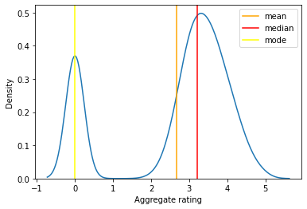

```python
#displaying the mean, median and mode
sns.kdeplot(data['Aggregate rating'])
plt.axvline(me, label='mean',color='Orange')
plt.axvline(md, label='median',color='Red')
plt.axvline(mod, label='mode',color='Yellow')

plt.legend()
plt.show()
```

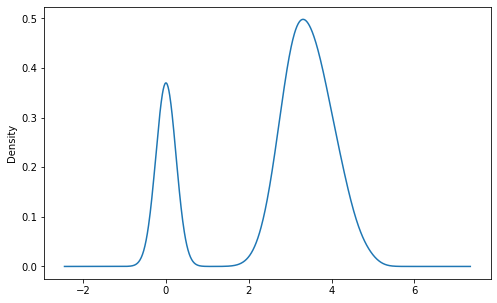

```python
plt.figure(figsize=(8,5))
data['Aggregate rating'].plot(kind='kde')
plt.show()
```

# Data Type Conversion

We are performing label encoding on categorical columns and try to generate a new columns out of those columns. The columns are: 'Has Table booking', 'Has Online delivery','Is delivering now', 'Switch to order menu',

```python
data[['Has Table booking', 'Has Online delivery','Is delivering now', 'Switch to order menu']]
```

|  | Has Table booking | Has Online delivery | Is delivering now | Switch to order menu |
| --- | --- | --- | --- | --- |
| 0 | Yes | No | No | No |
| 1 | Yes | No | No | No |
| 2 | Yes | No | No | No |
| 3 | No | No | No | No |
| 4 | Yes | No | No | No |
| ... | ... | ... | ... | ... |
| 9546 | No | No | No | No |
| 9547 | No | No | No | No |
| 9548 | No | No | No | No |
| 9549 | No | No | No | No |
| 9550 | No | No | No | No |

9551 rows × 4 columns

```python
data['Has Table booking'].value_counts()
```

```
No     8393
Yes    1158
Name: Has Table booking, dtype: int64
```

```python
from sklearn import preprocessing
```

```python
label_encoder=preprocessing.LabelEncoder()

data['Has_Table_booking_Encoded']=label_encoder.fit_transform(data['Has Table booking'])
data['Has_Table_booking_Encoded'].unique
```

```
<bound method Series.unique of 0       1
1       1
2       1
3       0
4       1
       ..
9546    0
9547    0
9548    0
9549    0
9550    0
Name: Has_Table_booking_Encoded, Length: 9551, dtype: int32>
```

```python
data['Has_Table_booking_Encoded'].value_counts() #No is represnted as 0 and Yes is represented as 1
```

```
0    8393
1    1158
Name: Has_Table_booking_Encoded, dtype: int64
```

```python
data['Has Online delivery'].value_counts()
```

```
No     7100
Yes    2451
Name: Has Online delivery, dtype: int64
```

## Feature Engineering - Creating New Column from different columns like-Has Online delivery,Is delivering now,Switch to order menu

```python
data['Has_Online_delivery_Encoded']=label_encoder.fit_transform(data['Has Online delivery'])
```

```python
data['Has_Online_delivery_Encoded'].value_counts()#No is represnted as 0 and Yes is represented as 1
```

```
0    7100
1    2451
Name: Has_Online_delivery_Encoded, dtype: int64
```

```python
data['Is delivering now'].value_counts()
```

```
No     9517
Yes      34
Name: Is delivering now, dtype: int64
```

```python
data['Is_delivering_now_Encoded']=label_encoder.fit_transform(data['Is delivering now'])
```

```python
data['Is_delivering_now_Encoded'].value_counts()#No is represnted as 0 and Yes is represented as 1
```

```
0    9517
1      34
Name: Is_delivering_now_Encoded, dtype: int64
```

```python
data['Switch to order menu'].value_counts()
```

```
No    9551
Name: Switch to order menu, dtype: int64
```

```python
data['Switch_to_order_menu_Encoded']=label_encoder.fit_transform(data['Switch to order menu'])
```

```python
data['Switch_to_order_menu_Encoded'].value_counts()#No is represnted as 0
```

```
0    9551
Name: Switch_to_order_menu_Encoded, dtype: int64
```

# Things to Perform:

#### Descriptive Analysis

#### Calculate basic statistical measures (mean, median, standard deviation, etc.) for numerical columns.

#### Explore the distribution of categorical variables like "Country Code", "City" and "Cuisines".

#### Identify the top cuisines and cities with the highest number of restaurants.

# Splitting the Data into Numerical and Categorical Data

```python
num_cols=data.select_dtypes(include='number')
```

```python
num_cols.columns
```

```
Index(['Restaurant ID', 'Country Code', 'Longitude', 'Latitude',
       'Average Cost for two', 'Price range', 'Aggregate rating', 'Votes',
       'Has_Table_booking_Encoded', 'Has_Online_delivery_Encoded',
       'Is_delivering_now_Encoded', 'Switch_to_order_menu_Encoded'],
      dtype='object')
```

```python
cat_cols=data.select_dtypes(include='object')
```

```python
cat_cols.columns
```

```
Index(['Restaurant Name', 'City', 'Address', 'Locality', 'Locality Verbose',
       'Cuisines', 'Currency', 'Has Table booking', 'Has Online delivery',
       'Is delivering now', 'Switch to order menu', 'Rating color',
       'Rating text'],
      dtype='object')
```